# Widow Rockfish

*Sebastes entomelas*

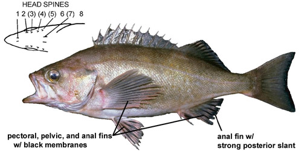

**Body color:** Uniform dusky-brown w/ traces of light yellow-red; fins brown to black, membranes of pectoral, pelvic, and anal fins black. Specimens < 10 in (25cm) w/ vague streaks of orange.

**Peritoneum color:** dark **Shape between eyes:** convex

**Counts:** D:XIII,14-16, Ar:7-10, P1:17-19, GR:34-38, LLp:52-60, LLs:58-66, V:26-27

**Occurence:** Gulf of Alaska - Baja California

**Depth:** 375 meters **Size:** 59 cm **Species code:** 30220

**Similar species:**

- *Yellowtail rockfish* - mouth large, maxilla extends beyond midorbit (maxilla extends anterior to midorbit in Widow RF); body brassy w/ yellow fins; anal-fin margin perpendicular
- *Black rockfish* - mouth large, maxilla extends beyond midorbit (maxilla extends anterior to midorbit in Widow RF) body dusky gray to black; anal-fin margin rounded; pectoral rays typically 19 (typically 18 in Widow RF)
- *Blue rockfish* - body blue to black w/ stripes on nape; body deep; dorsal rays typically 16 (typically 15 in Widow RF)
- *Light and Dark Dusky rockfish* - mouth large, maxilla extends beyond midorbit (maxilla anterior to midorbit in Widow RF); body deep; anal-fin margin perpendicular
- *Speckled rockfish* - speckling present on dorsum (absent in Widow RF); anal and pelvic-fin membranes dusky (black in Widow RF); gill rakers 29-34 and lateral line pores 45-55 (rakers 34-38 and pores 52-60 in Widow RF)

Back to Group

**Corrections:** If you see mistakes or want to suggest changes, please create an [issue](https://github.com/zoyafuso-NOAA/RACE_Survey_App/issues) on the source repository or

*reach out to Liz Dawson (Liz.Dawson AT noaa.gov).*